# Basic structural metrics

```r
library(igraph)
library(bipartite)
library(ggplot2)
```

# 1. Introduction

There is an endless number of metrics for netwrok structure in the general network science, and several more developed particularly for ecological networks. We will naturally focus on the most relevant and popular ones. It is very useful however to have a reference for the most popular ones. In the context of ecology, two papers are particulalry useful:

- *Dormann CF, Fründ J, Blüthgen N, Gruber B. Indices, graphs and null models: analyzing bipartite ecological networks. The Open Ecology Journal. 2009;2: 7–24.*
- *Delmas E, Besson M, Brice M-H, Burkle L, Dalla Riva GV, Fortin M-J, et al. Analyzing ecological networks of species interactions. bioRxiv. 2018. doi:10.1101/112540*

Though somewhat technical these are important references and we strongly suggest you have them at hand We will see more specific papers as we go along. We have also put several papers in the course material.

# 2. Bipartite networks

## 2.1 Some basic network metrics

Dormann et al. (2009, The Open Ecology Journal) classified bipartite network metrics into: 1. Metrics based on unweighted links 2. Metrics based on weighted links

Here are a few examples (see comments in code to learn what these are).

Calculate metrics:

```r
data(olesen2002flores) # Check out the help for information on this data set!
olesen2002flores_binary <- 1 * (olesen2002flores > 0) # Make the data binary (unweighted)
I <- nrow(olesen2002flores_binary) # Number of lower level species (e.g., hosts, plants)
J <- ncol(olesen2002flores_binary) # Number of higher level species (e.g., parasites, pollinators)
S <- I + J # Total number of species, aka: Network size
L <- sum(olesen2002flores_binary > 0) # Number of edges in the network
A_i <- rowSums(olesen2002flores_binary) # The degree of hosts
A_j <- colSums(olesen2002flores_binary) # The degree of parasites
C <- L / (I * J) # Connectance
cc_high <- colSums(olesen2002flores_binary) / nrow(olesen2002flores_binary) # Clustering coefficient higher level (the number of realized links divided by the number of possible links for each species)
cc_low <- rowSums(olesen2002flores_binary) / ncol(olesen2002flores_binary) # Clustering coefficient lower level (the number of realized links divided by the number of possible links for each species)
```

In a weighted network we can use strength instead of degree:

```r
S_i <- rowSums(olesen2002flores) # Node strength of hosts
S_j <- colSums(olesen2002flores) # Node strength of parasites
```

> 1. Try to calculate these metrics for the `memmott1999` data.
> 2. Can you plot the degree and strength distribtions?
> 3. What other metrics can you calculate which are not here? Where did you find them?

## 2.2 Built-in metrics in `bipartite`

We can of course, write code to calculate each metric but `bipartite` has many already implemented. The functions `specieslevel`, `grouplevel` and `networklevel` calculate metrics at these respective network levels. For example:

```r
# Species level:
sl_metrics <- specieslevel(olesen2002flores)
names(sl_metrics$`higher level`)
```

```
##  [1] "degree"                        "normalised.degree"
##  [3] "species.strength"              "interaction.push.pull"
##  [5] "nestedrank"                    "PDI"
##  [7] "resource.range"                "species.specificity.index"
##  [9] "PSI"                           "node.specialisation.index.NSI"
## [11] "betweenness"                   "weighted.betweenness"
## [13] "closeness"                     "weighted.closeness"
## [15] "Fisher.alpha"                  "partner.diversity"
## [17] "effective.partners"            "proportional.generality"
## [19] "proportional.similarity"       "d"
```

```r
sl_metrics$`higher level`$degree # The degree of flower visitors
```

```
##  [1] 6 4 1 3 3 4 3 2 1 1 1 1
```

```r
# Group level:
gl_metrics <- grouplevel(olesen2002flores)
gl_metrics
```

```
##              number.of.species.HL              number.of.species.LL
##                        12.0000000                        10.0000000
##           mean.number.of.links.HL           mean.number.of.links.LL
##                         3.8586479                         4.4582968
## mean.number.of.shared.partners.HL mean.number.of.shared.partners.LL
##                         0.7121212                         0.8222222
##            cluster.coefficient.HL            cluster.coefficient.LL
##                         0.3858648                         0.3715247
##   weighted.cluster.coefficient.HL   weighted.cluster.coefficient.LL
##                         0.2701252                         0.2148559
##                  niche.overlap.HL                  niche.overlap.LL
##                         0.2288755                         0.2205265
##                   togetherness.HL                   togetherness.LL
##                         0.1496212                         0.1534722
##                        C.score.HL                        C.score.LL
##                         0.5311448                         0.5455247
##                        V.ratio.HL                        V.ratio.LL
##                         1.4745763                         1.7346939
##                    discrepancy.HL                    discrepancy.LL
##                        14.0000000                        14.0000000
##               extinction.slope.HL               extinction.slope.LL
##                         2.6432617                         1.9712856
##                     robustness.HL                     robustness.LL
##                         0.7229661                         0.6601948
##     functional.complementarity.HL     functional.complementarity.LL
##                       900.4271365                       854.6445694
##              partner.diversity.HL              partner.diversity.LL
##                         0.9325640                         1.1013382
##                     generality.HL                  vulnerability.LL
##                         2.7505169                         3.4163571
```

```r
# Network level
nl_metrics <- networklevel(olesen2002flores)
nl_metrics
```

```
##                       connectance                     web asymmetry
##                        0.25000000                        0.09090909
##                 links per species            number of compartments
##                        1.36363636                        1.00000000
##             compartment diversity               cluster coefficient
##                                NA                        0.25000000
##                        nestedness               weighted nestedness
##                       26.73800218                        0.41007400
##                     weighted NODF    interaction strength asymmetry
##                       23.27327327                        0.06921118
##          specialisation asymmetry                   linkage density
##                       -0.03946187                        3.08343699
##              weighted connectance                      Fisher alpha
##                        0.14015623                        5.64808587
##                 Shannon diversity              interaction evenness
##                        2.99270826                        0.62510985
##      Alatalo interaction evenness                                H2
##                        0.76748398                        0.53335441
##              number.of.species.HL              number.of.species.LL
##                       12.00000000                       10.00000000
## mean.number.of.shared.partners.HL mean.number.of.shared.partners.LL
##                        0.71212121                        0.82222222
##            cluster.coefficient.HL            cluster.coefficient.LL
##                        0.38586479                        0.37152473
##   weighted.cluster.coefficient.HL   weighted.cluster.coefficient.LL
##                        0.27012517                        0.21485594
##                  niche.overlap.HL                  niche.overlap.LL
##                        0.22887547                        0.22052649
##                   togetherness.HL                   togetherness.LL
##                        0.14962121                        0.15347222
##                        C.score.HL                        C.score.LL
##                        0.53114478                        0.54552469
##                        V.ratio.HL                        V.ratio.LL
##                        1.47457627                        1.73469388
##                    discrepancy.HL                    discrepancy.LL
##                       14.00000000                       14.00000000
##               extinction.slope.HL               extinction.slope.LL
##                        2.72319223                        2.19859865
##                     robustness.HL                     robustness.LL
##                        0.72936271                        0.67855780
##     functional.complementarity.HL     functional.complementarity.LL
##                      900.42713645                      854.64456938
##              partner.diversity.HL              partner.diversity.LL
##                        0.93256402                        1.10133819
##                     generality.HL                  vulnerability.LL
##                        2.75051685                        3.41635714
```

> 4. Try to calculate and access metrics at the **species level** (e.g., host asssemblage or parasite assemblage) level. Use the help to discover which metrics `bipartite` has implemented.
> 5. Try to calculate and access metrics at the **guild level** (e.g., host asssemblage or parasite assemblage) level. Use the help to discover which metrics `bipartite` has implemented.
> 6. Read the description or the metric Interaction Strength Asymmetry in Dormann et al. 2009 (page 10). This can be calculated in `bipartite` like this: `specieslevel(memmott1999, index='interaction push pull')` Can you program that metric yourself and get the same results?

# 2.3 A specific example: degree distributions

One very cool implemetation in `bipartite` allows to examine the degree distributions. It tries to fit the distributions to examine if they are close to a power law.

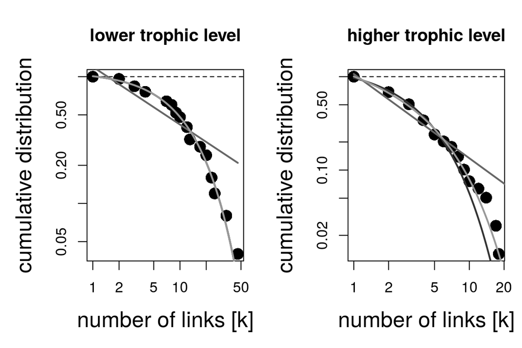

```
## $`lower level dd fits`
##                         Estimate  Std. Error     Pr(>|t|)        R2
## exponential          0.082498431 0.002476824 9.830478e-15 0.9970503
## power law            0.455391061 0.055567751 1.033153e-06 0.9226974
## truncated power law -0.001599012 0.031197499 9.599019e-01 0.9970531
##                           AIC
## exponential         -68.92055
## power law           -16.52451
## truncated power law -66.92373
##
## $`higher level dd fits`
##                      Estimate Std. Error     Pr(>|t|)        R2       AIC
## exponential         0.3160055 0.01316529 1.641891e-11 0.9966307 -56.23056
## power law           0.9017088 0.06389974 7.797697e-09 0.9794204 -33.33749
## truncated power law 0.2867555 0.05780953 4.285498e-04 0.9984914 -68.93422
```

```r
degreedistr(memmott1999)
```

# 3. Network projections

Many network metrics are only available for unipartite networks. One common strategy is to “project” a bipartite to an unipartite network. In its simplest form projecting is done by connecting a pair of nodes in set A of the bipartite network if they are both connected to at least one node in set B. An intuitive way to weigh the edges is by counting the number of nodes in B shared by the dyad in A. Let’s try that:

```r
# Original
networklevel(memmott1999, index='connectance')
```

```
## connectance
##   0.1513924
```

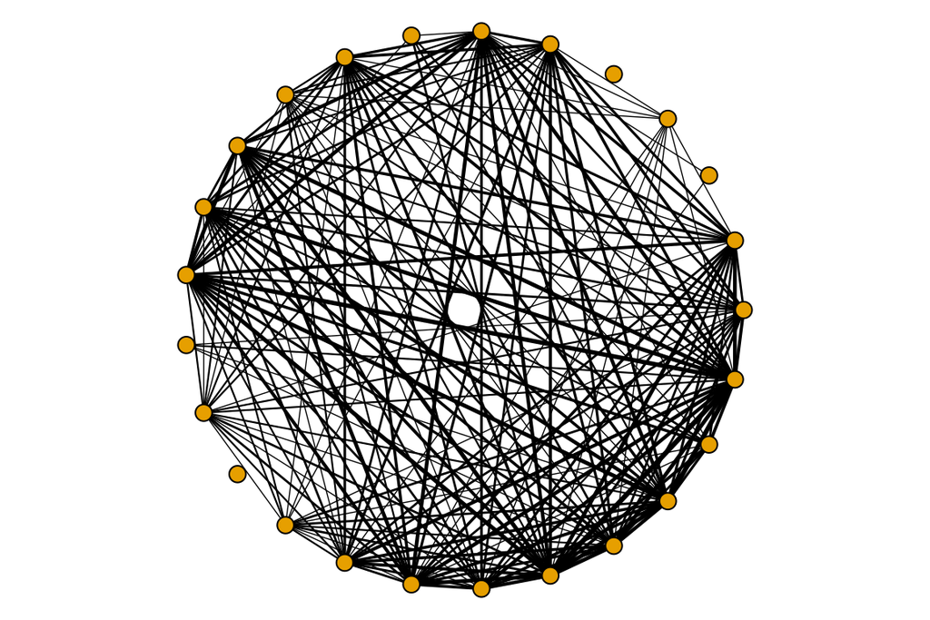

```r
# Project plants
plants_projected <- tcrossprod(memmott1999>0) # Number of shared pollinators
diag(plants_projected) <- 0
g <- graph.adjacency(plants_projected, mode = 'undirected', weighted = T)
par(mar=c(0,0,0,0))
plot(g, vertex.size=6, vertex.label=NA, edge.color='black', edge.width=log(E(g)$weight), layout=layout.circle)
```

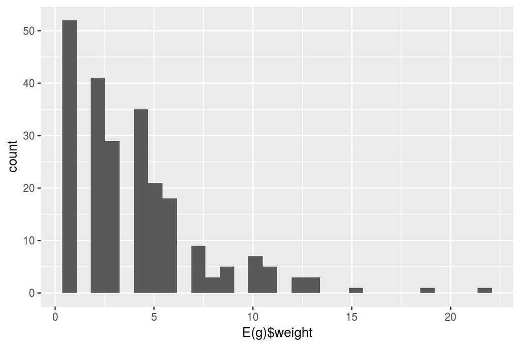

```r
qplot(E(g)$weight)
```

> 7. try to project the pollinators

It is also possible to integrate the weights of the edges in the projection. This function in bipartite sums the edge weights of the edges as well.

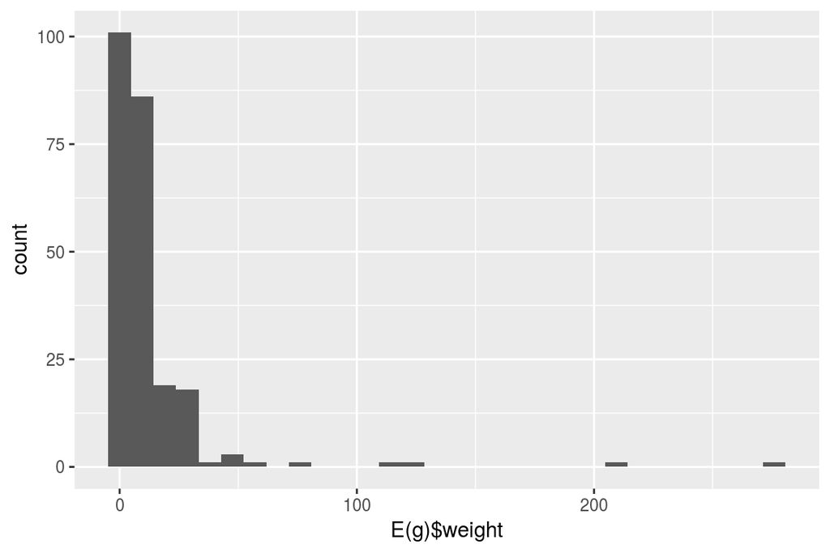

```r
plants_projected <- as.one.mode(memmott1999, project = 'lower')
g <- graph.adjacency(plants_projected, mode = 'undirected', weighted = T)
qplot(E(g)$weight)
```

Notice the difference in edge weights.

> 8. What information do we lose when projecting?
> 9. What can you say about the density of the projected networks?
> 10. What is the ecological interpretation of the projections of a plant-pollinator network and of a host-parasite network?

# 4. Unipartite networks

Metrics for unipartite graphs have been developed much before those for bipartite networks and there are many more of them. To get us started, let’s load data and start exploring.

```r
# First, load the data
otago_nodes <- read.csv('https://raw.githubusercontent.com/pascualgroup/Networks_course/master/Network_data/Otago_Data_Nodes.csv?token=ADd8ONa_lfqD2gKIE5h7vig2-1_xfezXks5azMwWwA%3D%3D')
otago_links <- read.csv('https://raw.githubusercontent.com/pascualgroup/Networks_course/master/Network_data/Otago_Data_Links.csv?token=ADd8ONRlDulEIlfx0L0qUfayAEPtQlfIks5azMwlwA%3D%3D')
otago_web <- graph.data.frame(otago_links, vertices = otago_nodes, directed = T)

# Also load a weighted food web
chesapeake_nodes <- read.csv('https://raw.githubusercontent.com/pascualgroup/Networks_course/master/Network_data/Chesapeake_bay_nodes.csv?token=ADd8OP102bE0HzQNE_1hondsNVhvFiRjks5azMxFwA%3D%3D', header=F)
names(chesapeake_nodes) <- c('nodeId','species_name')
chesapeake_links <- read.csv('https://raw.githubusercontent.com/pascualgroup/Networks_course/master/Network_data/Chesapeake_bay_links.csv?token=ADd8OFq6aj3oEZ84lFQ05iJ0Yu3cQ8qZks5azMxWwA%3D%3D', header=F)
names(chesapeake_links) <- c('from','to','weight')
ches_web <- graph.data.frame(chesapeake_links, vertices = chesapeake_nodes, directed = T)
# plot(ches_web, edge.width=log(E(ches_web)$weight)/2, layout=layout.circle)
```

These networks come from the following sources:

- Otago web: *Mouritsen KN, Poulin R, McLaughlin JP, Thieltges DW. Food web including metazoan parasites for an intertidal ecosystem in New Zealand. Ecology. Wiley Online Library; 2011;92: 2006–2006.*, with a description [here](http://esapubs.org/archive/ecol/E092/173/metadata.htm).
- Chesapeake bay: *Baird D, Ulanowicz RE. The Seasonal Dynamics of The Chesapeake Bay Ecosystem. Ecol Monogr. Ecological Society of America; 1989;59: 329–364.* Data set is from [here](http://vlado.fmf.uni-lj.si/pub/networks/data/bio/foodweb/foodweb.htm)

# 4.1 Degree and strength

The Otago data is unweighted, so we can not calcualte strength. It is also directed, which means we can separate the in-degree and out-degree. Let’s take a look at these values. We will use `ggplot` to plot the distributions.

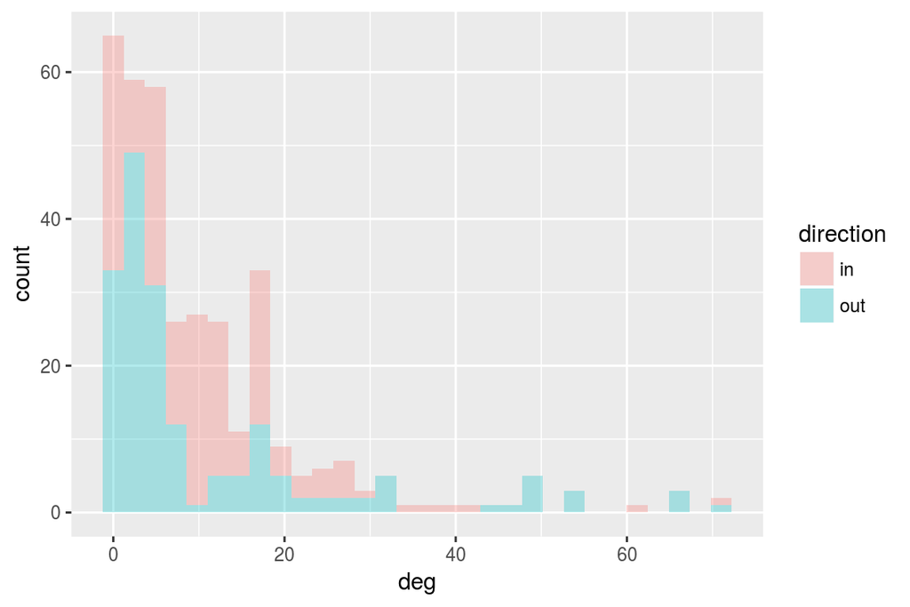

```r
deg_dist_out <- igraph::degree(otago_web, mode = 'out')
deg_dist_in <- igraph::degree(otago_web, mode = 'in')
df <- data.frame(deg=c(deg_dist_out,deg_dist_in), direction=c(rep('out',length(deg_dist_in)),rep('in',length(deg_dist_in))))
ggplot(df, aes(deg, fill=direction))+geom_histogram(alpha=0.3)
```

> 11. Degree (and strength) can be calculated directly from the matrix version of the network. In-degree is $\sum\limits_{j=1}^J {a_{ij}}$ and out-degree is $\sum\limits_{i=1}^I {a_{ij}}$. Try to transform the Otago web to an adjacency matrix (like we did in the previous class), then calculate node in-degree and out-degree using the matrix.

The Chesapeake Bay food web is weighted as it describes flow of carbon. So we can calcualte degree and strength:

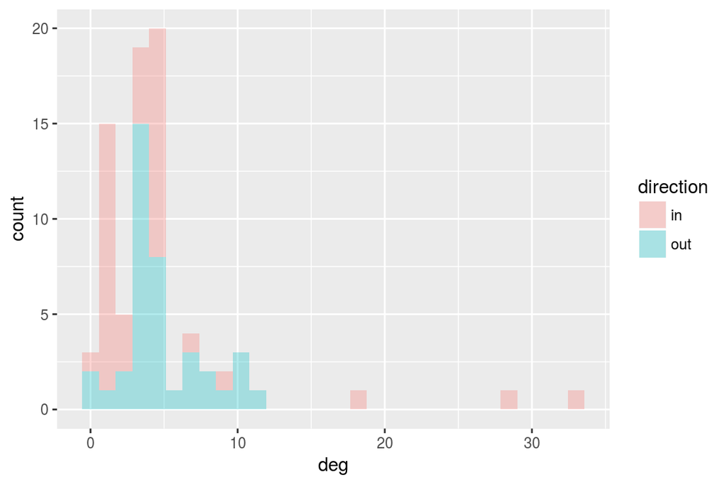

```r
deg_dist_out <- igraph::degree(ches_web, mode = 'out')
deg_dist_in <- igraph::degree(ches_web, mode = 'in')
df <- data.frame(deg=c(deg_dist_out,deg_dist_in), direction=c(rep('out',length(deg_dist_in)),rep('in',length(deg_dist_in))))
ggplot(df, aes(deg, fill=direction))+geom_histogram(alpha=0.3)
```

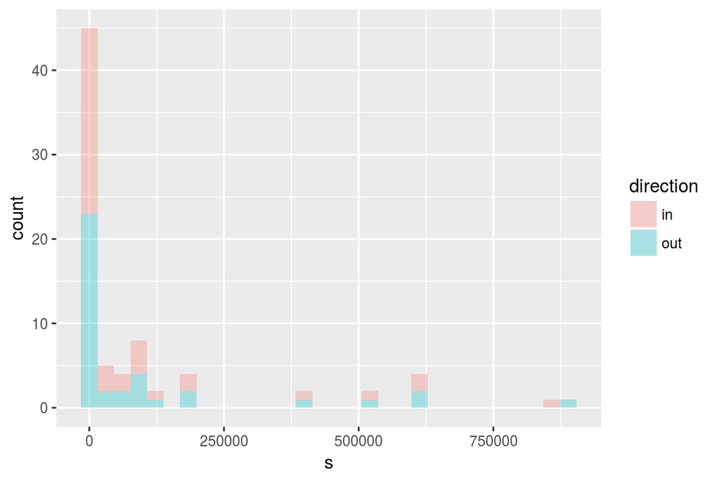

```r
s_dist_out <- igraph::strength(ches_web, mode = 'out')
s_dist_in <- igraph::strength(ches_web, mode = 'in')
df <- data.frame(s=c(s_dist_out,s_dist_in),
                 direction=c(rep('out',length(s_dist_in)),rep('in',length(s_dist_in))))
ggplot(df, aes(s, fill=direction))+geom_histogram(alpha=0.3)
```

> 12. Can discrepancies in in-degree and out-degree (or strength) give us some ecological insight?

# 4.2 Clustering coefficient

The clustering coefficient is a measure of local clustering in a network. It can be defined either locally, per node (number of triangles divided by number of triples), or globally.

```r
transitivity(otago_web, type = 'local') # The ratio of the triangles connected to the vertex and the triples centered on the vertex.
```

```
##   [1] 0.20952381 0.09068323 0.21739130 0.28654971 0.16169631 0.09360127
##   [7] 0.10195035 0.20588235 0.26315789 0.26315789 0.10256410 0.30882353
##  [13] 0.30882353 0.00000000 0.13333333 0.38333333 0.20512821 0.20512821
##  [19] 0.38412698 0.58479532 0.58479532 0.23894558 0.43939394 0.21428571
##  [25] 0.21428571 0.21428571 0.00000000 0.38181818 0.21428571 0.34640523
##  [31] 0.34640523 0.17142857 0.29743590 0.29743590 0.29743590 0.30049261
##  [37] 0.30344828 0.28225806 0.00000000 0.27000000 0.17308489 0.12359551
##  [43] 0.12359551 0.40000000 0.42105263 0.51052632 0.20000000 0.39886040
##  [49] 0.38461538 0.33333333 0.24264706 0.46825397 0.33333333 0.33333333
##  [55] 0.00000000 0.22500000 0.00000000 0.00000000 0.00000000 0.26315789
##  [61] 0.31428571 0.11764706 0.10256410 0.20000000 0.24242424 0.15238095
##  [67] 0.21718931 0.24242424 0.30924370 0.27807487 0.38412698 0.24242424
##  [73] 0.60000000 0.22480620 0.22318841 0.50000000 0.39743590 0.13888889
##  [79] 0.17948718 0.17948718 0.20000000 0.48421053 0.40000000 0.21052632
##  [85] 0.21052632 0.42365591 0.31159420 0.17142857 0.24367816 0.24367816
##  [91] 0.12667579 0.73333333 0.35555556 0.42666667 0.42666667 0.45059289
##  [97] 0.40000000 0.40000000 0.00000000 0.12121212 0.32967033 0.13269231
## [103] 0.28571429 0.28571429 0.28138528 0.26984127 0.13909774 0.10803891
## [109] 0.24264706 0.12896175 0.10776942 0.17094017 0.20000000 0.06926407
## [115] 0.25000000 0.10039216 0.15019763 0.04736842 0.10114943 0.33333333
## [121] 0.00000000 0.19762846 0.19762846 0.00000000 0.60256410 0.70000000
## [127] 0.24178896 0.00000000 0.60256410 0.22539683 0.30039526 0.00000000
## [133] 0.60256410 0.70000000 0.30011074 0.00000000 0.70476190 0.70000000
## [139] 0.27472527 0.00000000 0.60256410 0.46666667 0.44736842 0.00000000
## [145] 0.69166667 0.70000000 0.34502924 0.00000000 0.80555556 0.46666667
## [151] 0.48538012 0.00000000 0.69166667 0.46666667 0.48538012 0.00000000
## [157] 0.39743590 0.70000000 0.48538012 0.27472527 0.50000000 0.70000000
## [163] 0.00000000 0.09090909 0.29437229 0.00000000 0.32900433 0.00000000
## [169] 0.32900433 0.12727273 0.35238095 0.31818182        NaN 0.48538012
## [175] 0.70000000 0.00000000 0.80000000 0.66666667 0.27472527 0.16483516
```

```r
transitivity(otago_web, type = 'global') # The ratio of the triangles and the connected triples in the graph
```

```
## [1] 0.2203512
```

> 13. What can a high local clustering coefficient indicate in a food web?

# 4.3 Metrics related to geodesics

Geodesics (shortest paths) are at the basis of many metrics, including centrality. First let’s learn to obtain a distance table matrix.

```r
geodesics <- distances(otago_web, mode = 'all') # Assume an undirected graph
geodesics[1:5,1:5]
```

```
##   1 2 3 4 5
## 1 0 2 2 1 1
## 2 2 0 2 2 1
## 3 2 2 0 2 1
## 4 1 2 2 0 1
## 5 1 1 1 1 0
```

# 4.4 Node centrality

There are many centrality metrics, each with dozens of variations. Let’s take a look at the few common ones. Note that it is common to normalize the centrality measures. This is particularly helpful when comparing across networks. Read more about that normalization in the help and in *Delmas et al (2018)*.

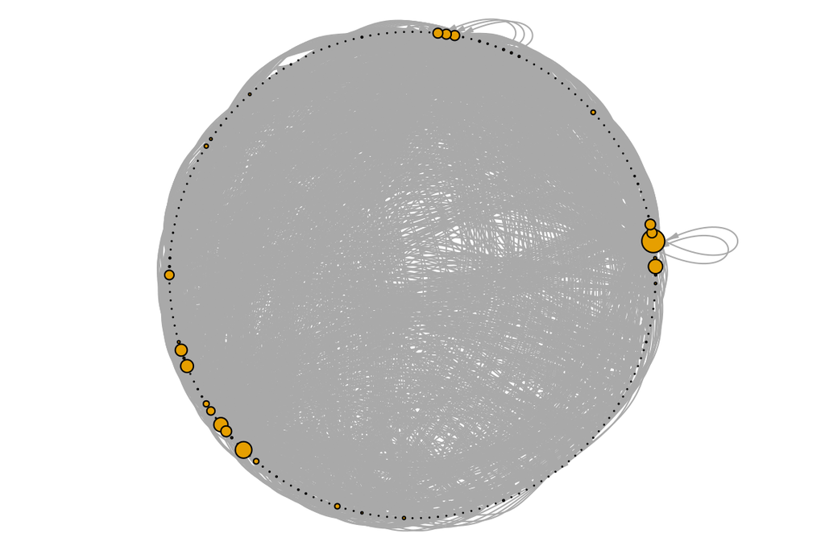

```r
# Assume undirected networks
CC <- igraph::closeness(otago_web, mode = 'all', normalized = T)
BC <- igraph::betweenness(otago_web, directed = F, normalized = T)
EC <- igraph::eigen_centrality(otago_web, directed = F, scale = T)
EC <- EC$vector

# Plot the web, re-sizing nodes by centrality.
V(otago_web)$BC <- BC
par(mar=c(0,0,0,0))
plot(otago_web, vertex.size=BC*100, vertex.label=NA, edge.arrow.width=0.5, edge.arrow.size=0.5, edge.curved=0.5, layout=layout.circle)
```

> 14. Try to calculate the centrality measures for directed food webs.
> 15. Can you think of an ecological interpretation to each of these measures? Some intuition is given in the *Martín-González et al. (2010)* and *Delmas et al. (2018)* references.
> 16. What do you think would be the correlation beween these measures? Test it!
> 17. Which are the most central species in the network? Do they have anything in common?

# 4.4 Motifs

Recall that motifs are sub-structural patterns composing a network. Motifs are only meaningful in directed networks. For triplets, there are 16 kinds of motifs. See them by calling help: `?triad.census`. Let’s plot them.

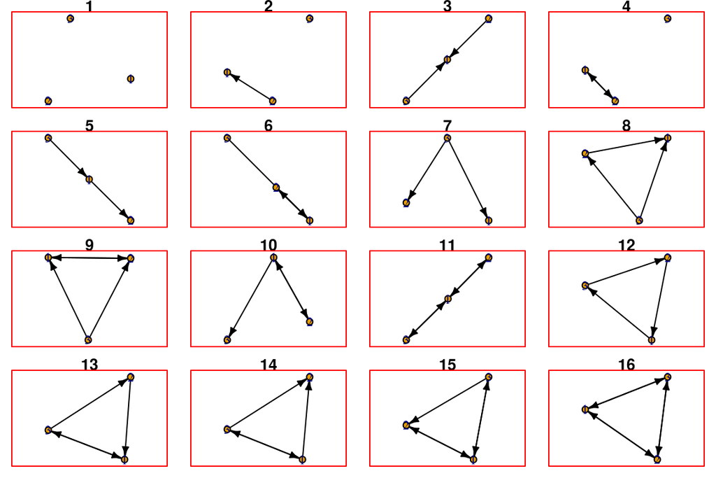

```r
par(mfrow=c(4,4), mar=c(.75,.75,.75,.75))
for (i in 0:15){ # note that counting starts at 0
  plot(graph_from_isomorphism_class(size = 3, number = i),
       edge.arrow.size = 0.4,
       edge.color='black',
       main = i + 1)
  box(col='red')
}
```

Each of these different classes of motifs can have an ecological meaning. For example, motif #3 means that two prey share a predator and #5 is a trophic chain. It is therefoul insightful to quantify how many of each kind are in the food web.

```r
motifs(otago_web) #absolute numbers
```

```
##  [1]    NA    NA 12506    NA 10956   491 22120  3434   533  2287   117
## [12]    18    57   376   100    49
```

```r
motifs(otago_web)/count_motifs(otago_web) # Proportion
```

```
##  [1]           NA           NA 0.2357665334           NA 0.2065455094
##  [6] 0.0092564663 0.4170122917 0.0647387075 0.0100482618 0.0431151497
## [11] 0.0022057160 0.0003393409 0.0010745796 0.0070884549 0.0018852274
## [16] 0.0009237614
```

> 18. What is the dominant motif in the Otago food web? What is it’s ecological meaning?
> 19. Calculate the propotion of motifs for the Bahia Falsa food web. Is the relative frequency of motifs in this food web different than the Otago food web?

# 5. Suggested reading

Some papers which develop or explain specific metrics:

- *Bersier L-F, Banašek-Richter C, Cattin M-F. Quantitative Descriptors of Food-Web Matrices. Ecology. Ecological Society of America; 2002; 83:2394–2407.*
- *Blüthgen N, Menzel F, Blüthgen N. Measuring specialization in species interaction networks. BMC Ecol. 2006;6: 9.*
- *Martín González AM, Dalsgaard B, Olesen JM. Centrality measures and the importance of generalist species in pollination networks. Ecol Complex. 2010; 7:36–43.*
- *Poisot T, Canard E, Mouquet N, Hochberg ME. A comparative study of ecological specialization estimators. Methods Ecol Evol. 2012; 3:537–544.*